# Elder_R_Lab_Webscraping_DataCollection_s

Rename this lab as "Yourlastname_firstinitial_Lab_Webscraping_DataCollection". You need to submit html file.

### All Lab/HWs will be graded based on three criteria:

1. Mechanical correctness of your python codes: your codes must be accurate
2. Clarity of jupyter notebook and organization of outputs:
- The python codes you write must be accompanied with "comments" using # or markdown
- All outputs must be visible in your jupyter notebook. If necessary, explain the outputs using markdown.
- **Do not print out an entire output. Print the first two or five rows**
1. Formatting: **"All Labs / HWs must contain K-State Honor Code "On my honor, as a student, I have neither given nor received unauthorized aid on this academic work."**
   - A **grade of XF** can result from a breach of academic honesty. The F indicates failure in the course; the X indicates the reason is an Honor Pledge violation.” (http://www.k-state.edu/provost/resources/teaching/course.htm (Links to an external site.)) (See Academic Dishonesty below).
- **Unauthorized collaboration** (including but not limited to collaborating with other students on lab, HW, the midterm exam, and the final project is forbidden)
- **Unauthorized aid** (including but not limited to sharing your codes with other students, receiving codes from another)
- Plagiarism (including but not limited to copying words of another (on the Internet or articles) as your own)

**K-State Honor Code**

> All Labs / HWs must contain K-State Honor Code "On my honor, as a student, I have neither given nor received unauthorized aid on this academic work.

**Your Name:**

> Ross Elder

# Data Analytics Project Lifecycle

```python
from IPython.display import Image
from IPython.core.display import HTML
Image(url= "https://upload.wikimedia.org/wikipedia/commons/b/b9/CRISP-DM_Process_Diagram.png",width=600,height=600)
```

[figure not shown]

# Web scraping for Data Collection

Web scraping is one popular method to collect data from the web. This method requires some knowledge of html & **xpath**.

When you collect the data from websites, you need to be mindful about the website's terms and conditions. Two examples below are created for educational purpose.

# XPath Cheat Sheets

- Go to http://ricostacruz.com/cheatsheets/xpath.html

# Python modules used in this lecture

1. For web scraping, you need to use a python moduel (or package) called **Request** to **access HTML file or web page**
2. Then, **HTML and XML need to be processed** using **lxml**, a Python package
3. **pandas** Python modules for **saving data in csv files**

```python
# import python packages for web scraping
import requests
from lxml import html

# csv and pandas
import csv
import pandas as pd

# python package for data visualization
%matplotlib inline
import matplotlib.pyplot as plt

import warnings
warnings.filterwarnings("ignore", category=FutureWarning)

# show 1000 rows
pd.set_option('display.max_rows', 1000)
```

# Example: Craiglist http://sfbay.craigslist.org/search/npo

- Use Google Chrome for the following:
- Go to http://sfbay.craigslist.org/search/npo
- We will inspect **the source page** to develop **Xpath** for the information we're looking for. **Right Click** and select **Inspect**. This will show the source HTML code.

The first step is finding the repeatable html code for the site. In this website, it is code for each job post which starts with div[@class='result-info'].

```python
# visit the webpage and access the web contents
r = requests.get('http://sfbay.craigslist.org/search/npo')
data = html.fromstring(r.text)

# xpath: collect the specific data you're looking for

for i in data.xpath("//div[@class='result-info']"):
    title =  i.xpath("h3[@class='result-heading']/a/text()")
    url =   i.xpath("h3[@class='result-heading']/a/@href")
    print(title, url)
```

```
['Food Pantry Packer'] ['https://sfbay.craigslist.org/pen/npo/d/daly-city-food-pantry-packer/7439995355.html']
['Resident Services Coordinator'] ['https://sfbay.craigslist.org/nby/npo/d/corte-madera-resident-services/7439976520.html']
['En2action | Project Manager'] ['https://sfbay.craigslist.org/sfc/npo/d/san-francisco-en2action-project-manager/7439939472.html']
['Entry Level- Adult Day Program Instructor'] ['https://sfbay.craigslist.org/eby/npo/d/martinez-entry-level-adult-day-program/7439441762.html']
['Mental Health & Wellness Director'] ['https://sfbay.craigslist.org/eby/npo/d/oakland-mental-health-wellness-director/7439428624.html']
['Restoration Technician'] ['https://sfbay.craigslist.org/nby/npo/d/eldridge-restoration-technician/7439354033.html']
['Accounting Associate'] ['https://sfbay.craigslist.org/nby/npo/d/santa-rosa-accounting-associate/7439292004.html']
['Church organist/pianist needed, permanent'] ['https://sfbay.craigslist.org/nby/npo/d/novato-church-organist-pianist-needed/7439254209.html']
['Operations Coordinator'] ['https://sfbay.craigslist.org/scz/npo/d/santa-cruz-operations-coordinator/7439086774.html']
['Program Manager Bilingual (Spanish/English)'] ['https://sfbay.craigslist.org/eby/npo/d/oakland-program-manager-bilingual/7439007492.html']
['Development and Communications Manager Bilingual (Spanish/English)'] ['https://sfbay.craigslist.org/eby/npo/d/oakland-development-and-communications/7439006103.html']
['Order Builder'] ['https://sfbay.craigslist.org/sfc/npo/d/san-francisco-order-builder/7438960720.html']
['Lead Distribution Clerk'] ['https://sfbay.craigslist.org/sfc/npo/d/san-francisco-lead-distribution-clerk/7438959495.html']
['Training Kennel Technician at Guide Dogs for the Blind'] ['https://sfbay.craigslist.org/nby/npo/d/el-verano-training-kennel-technician-at/7438958639.html']
['Resource Counselor - PART TIME'] ['https://sfbay.craigslist.org/nby/npo/d/corte-madera-resource-counselor-part/7438939499.html']
['Clinical Director for Psychotherapy Community Clinic'] ['https://sfbay.craigslist.org/eby/npo/d/berkeley-clinical-director-for/7438917645.html']
['Case  Manager I, CS-South'] ['https://sfbay.craigslist.org/sfc/npo/d/san-francisco-case-manager-cs-south/7438914575.html']
['Case Manager I -Full-time (Community Living Funds)'] ['https://sfbay.craigslist.org/sfc/npo/d/san-francisco-case-manager-full-time/7438900665.html']
['THE PARTNERSHIP FOR THE BAY’S FUTURE FELLOWSHIP'] ['https://sfbay.craigslist.org/sfc/npo/d/san-francisco-the-partnership-for-the/7438887695.html']
['Manager of Facilitation'] ['https://sfbay.craigslist.org/pen/npo/d/san-mateo-manager-of-facilitation/7438852458.html']
['Facilitator'] ['https://sfbay.craigslist.org/pen/npo/d/san-mateo-facilitator/7438849276.html']
['Community Engagement Specialist'] ['https://sfbay.craigslist.org/pen/npo/d/san-mateo-community-engagement/7438845101.html']
['Workplace Effectiveness Associate'] ['https://sfbay.craigslist.org/pen/npo/d/san-mateo-workplace-effectiveness/7438842460.html']
['Development and Marketing Manager'] ['https://sfbay.craigslist.org/sfc/npo/d/san-francisco-development-and-marketing/7438835867.html']
['Recovery Residence Lead'] ['https://sfbay.craigslist.org/pen/npo/d/san-mateo-recovery-residence-lead/7438832805.html']
['Re-Entry Specialist, MIOCR *800.00 Bonus*'] ['https://sfbay.craigslist.org/eby/npo/d/fairfield-re-entry-specialist-miocr/7438822457.html']
['Maintenance Person (Floater) - HAF'] ['https://sfbay.craigslist.org/eby/npo/d/oakland-maintenance-person-floater-haf/7438816870.html']
['Client Services Coordinator'] ['https://sfbay.craigslist.org/eby/npo/d/hayward-client-services-coordinator/7438797002.html']
['SUD Residential Monitors (On-Call)'] ['https://sfbay.craigslist.org/eby/npo/d/hayward-sud-residential-monitors-on-call/7438796189.html']
['Service Coordinator: Dental Program'] ['https://sfbay.craigslist.org/sfc/npo/d/san-francisco-service-coordinator/7438783281.html']
['Mental Health Team Leader'] ['https://sfbay.craigslist.org/sfc/npo/d/san-francisco-mental-health-team-leader/7438659554.html']
['Manager of Everyday Day Connect Services (EDC)'] ['https://sfbay.craigslist.org/sfc/npo/d/san-francisco-manager-of-everyday-day/7438533843.html']
['Local nonprofit seeks Intake Coordinator'] ['https://sfbay.craigslist.org/nby/npo/d/kentfield-local-nonprofit-seeks-intake/7438530038.html']
['Recruitment and Relations Manager'] ['https://sfbay.craigslist.org/eby/npo/d/oakland-recruitment-and-relations/7438491820.html']
['AOD Counselor'] ['https://sfbay.craigslist.org/nby/npo/d/napa-aod-counselor/7438487505.html']
['Clinical Supervisor in Solano (Sign-On Bonus)'] ['https://sfbay.craigslist.org/eby/npo/d/fairfield-clinical-supervisor-in-solano/7438486575.html']
['Clinical Supervisor in Sonoma (Sign-On Bonus)'] ['https://sfbay.craigslist.org/nby/npo/d/santa-rosa-clinical-supervisor-in/7438486334.html']
['Join ALDEA Therapist team! Sign-On Bonus & Bilingual Pay'] ['https://sfbay.craigslist.org/nby/npo/d/napa-join-aldea-therapist-team-sign-on/7438485030.html']
['Bilingual Therapist - Aldea Courage Center ($1,000 Sign-On Bonus)'] ['https://sfbay.craigslist.org/nby/npo/d/napa-bilingual-therapist-aldea-courage/7438484807.html']
['Join ALDEA team! Therapist Sign-On Bonus & Bilingual Spanish Pay'] ['https://sfbay.craigslist.org/nby/npo/d/santa-rosa-join-aldea-team-therapist/7438484057.html']
```

[output cut: 65 more lines]

```
['Weekend Support Staff'] ['https://sfbay.craigslist.org/nby/npo/d/san-rafael-weekend-support-staff/7437484597.html']
['Living Skills Trainer'] ['https://sfbay.craigslist.org/nby/npo/d/san-quentin-living-skills-trainer/7437389918.html']
['Overnight Living Skills Trainer'] ['https://sfbay.craigslist.org/nby/npo/d/san-quentin-overnight-living-skills/7437389029.html']
['Program Director, Peer Counseling for Older Adults'] ['https://sfbay.craigslist.org/pen/npo/d/san-mateo-program-director-peer/7437256901.html']
['IMMEDIATE JOB OPENINGS IN FREMONT'] ['https://sfbay.craigslist.org/sby/npo/d/hayward-immediate-job-openings-in/7437252401.html']
['IMMEDIATE JOB OPENINGS IN FREMONT'] ['https://sfbay.craigslist.org/eby/npo/d/hayward-immediate-job-openings-in/7437252195.html']
['IMMEDIATE JOB OPENINGS IN FREMONT'] ['https://sfbay.craigslist.org/eby/npo/d/hayward-immediate-job-openings-in/7437252037.html']
['IMMEDIATE JOB OPENINGS IN FREMONT'] ['https://sfbay.craigslist.org/eby/npo/d/hayward-immediate-job-openings-in/7437251891.html']
['Caregiver for Disabled Man – $28/hr or $2000/mo + Free Room and B'] ['https://sfbay.craigslist.org/nby/npo/d/santa-rosa-caregiver-for-disabled-man/7437240421.html']
['Residential Counselor - Huckleberry House - Spanish Required'] ['https://sfbay.craigslist.org/sfc/npo/d/san-francisco-residential-counselor/7437220948.html']
['Social Worker (Transition Age Youth Housing Programs)'] ['https://sfbay.craigslist.org/nby/npo/d/social-worker-transition-age-youth/7437166615.html']
['Maintenance Specialist'] ['https://sfbay.craigslist.org/nby/npo/d/sebastopol-maintenance-specialist/7437162707.html']
['Accounting Assistant (Part-Time or Full-Time)'] ['https://sfbay.craigslist.org/sfc/npo/d/san-francisco-accounting-assistant-part/7437140157.html']
['Regional Organizer Wanted at Racial Justice Non-Profit'] ['https://sfbay.craigslist.org/sfc/npo/d/san-francisco-regional-organizer-wanted/7437130065.html']
['Executive Assistant for Racial Justice Org'] ['https://sfbay.craigslist.org/sfc/npo/d/san-francisco-executive-assistant-for/7437129778.html']
```

```python
finaldata = []  # to save the collected data

for i in data.xpath("//div[@class='result-info']"):
    title =  i.xpath("h3[@class='result-heading']/a/text()")
    url =   i.xpath("h3[@class='result-heading']/a/@href")
    print(title, url)
    finaldata.append([title, url])  # to save the collected data

len(finaldata)
```

```
['Food Pantry Packer'] ['https://sfbay.craigslist.org/pen/npo/d/daly-city-food-pantry-packer/7439995355.html']
['Resident Services Coordinator'] ['https://sfbay.craigslist.org/nby/npo/d/corte-madera-resident-services/7439976520.html']
['En2action | Project Manager'] ['https://sfbay.craigslist.org/sfc/npo/d/san-francisco-en2action-project-manager/7439939472.html']
['Entry Level- Adult Day Program Instructor'] ['https://sfbay.craigslist.org/eby/npo/d/martinez-entry-level-adult-day-program/7439441762.html']
['Mental Health & Wellness Director'] ['https://sfbay.craigslist.org/eby/npo/d/oakland-mental-health-wellness-director/7439428624.html']
['Restoration Technician'] ['https://sfbay.craigslist.org/nby/npo/d/eldridge-restoration-technician/7439354033.html']
['Accounting Associate'] ['https://sfbay.craigslist.org/nby/npo/d/santa-rosa-accounting-associate/7439292004.html']
['Church organist/pianist needed, permanent'] ['https://sfbay.craigslist.org/nby/npo/d/novato-church-organist-pianist-needed/7439254209.html']
['Operations Coordinator'] ['https://sfbay.craigslist.org/scz/npo/d/santa-cruz-operations-coordinator/7439086774.html']
['Program Manager Bilingual (Spanish/English)'] ['https://sfbay.craigslist.org/eby/npo/d/oakland-program-manager-bilingual/7439007492.html']
['Development and Communications Manager Bilingual (Spanish/English)'] ['https://sfbay.craigslist.org/eby/npo/d/oakland-development-and-communications/7439006103.html']
['Order Builder'] ['https://sfbay.craigslist.org/sfc/npo/d/san-francisco-order-builder/7438960720.html']
['Lead Distribution Clerk'] ['https://sfbay.craigslist.org/sfc/npo/d/san-francisco-lead-distribution-clerk/7438959495.html']
['Training Kennel Technician at Guide Dogs for the Blind'] ['https://sfbay.craigslist.org/nby/npo/d/el-verano-training-kennel-technician-at/7438958639.html']
['Resource Counselor - PART TIME'] ['https://sfbay.craigslist.org/nby/npo/d/corte-madera-resource-counselor-part/7438939499.html']
['Clinical Director for Psychotherapy Community Clinic'] ['https://sfbay.craigslist.org/eby/npo/d/berkeley-clinical-director-for/7438917645.html']
['Case  Manager I, CS-South'] ['https://sfbay.craigslist.org/sfc/npo/d/san-francisco-case-manager-cs-south/7438914575.html']
['Case Manager I -Full-time (Community Living Funds)'] ['https://sfbay.craigslist.org/sfc/npo/d/san-francisco-case-manager-full-time/7438900665.html']
['THE PARTNERSHIP FOR THE BAY’S FUTURE FELLOWSHIP'] ['https://sfbay.craigslist.org/sfc/npo/d/san-francisco-the-partnership-for-the/7438887695.html']
['Manager of Facilitation'] ['https://sfbay.craigslist.org/pen/npo/d/san-mateo-manager-of-facilitation/7438852458.html']
['Facilitator'] ['https://sfbay.craigslist.org/pen/npo/d/san-mateo-facilitator/7438849276.html']
['Community Engagement Specialist'] ['https://sfbay.craigslist.org/pen/npo/d/san-mateo-community-engagement/7438845101.html']
['Workplace Effectiveness Associate'] ['https://sfbay.craigslist.org/pen/npo/d/san-mateo-workplace-effectiveness/7438842460.html']
['Development and Marketing Manager'] ['https://sfbay.craigslist.org/sfc/npo/d/san-francisco-development-and-marketing/7438835867.html']
['Recovery Residence Lead'] ['https://sfbay.craigslist.org/pen/npo/d/san-mateo-recovery-residence-lead/7438832805.html']
['Re-Entry Specialist, MIOCR *800.00 Bonus*'] ['https://sfbay.craigslist.org/eby/npo/d/fairfield-re-entry-specialist-miocr/7438822457.html']
['Maintenance Person (Floater) - HAF'] ['https://sfbay.craigslist.org/eby/npo/d/oakland-maintenance-person-floater-haf/7438816870.html']
['Client Services Coordinator'] ['https://sfbay.craigslist.org/eby/npo/d/hayward-client-services-coordinator/7438797002.html']
['SUD Residential Monitors (On-Call)'] ['https://sfbay.craigslist.org/eby/npo/d/hayward-sud-residential-monitors-on-call/7438796189.html']
['Service Coordinator: Dental Program'] ['https://sfbay.craigslist.org/sfc/npo/d/san-francisco-service-coordinator/7438783281.html']
['Mental Health Team Leader'] ['https://sfbay.craigslist.org/sfc/npo/d/san-francisco-mental-health-team-leader/7438659554.html']
['Manager of Everyday Day Connect Services (EDC)'] ['https://sfbay.craigslist.org/sfc/npo/d/san-francisco-manager-of-everyday-day/7438533843.html']
['Local nonprofit seeks Intake Coordinator'] ['https://sfbay.craigslist.org/nby/npo/d/kentfield-local-nonprofit-seeks-intake/7438530038.html']
['Recruitment and Relations Manager'] ['https://sfbay.craigslist.org/eby/npo/d/oakland-recruitment-and-relations/7438491820.html']
['AOD Counselor'] ['https://sfbay.craigslist.org/nby/npo/d/napa-aod-counselor/7438487505.html']
['Clinical Supervisor in Solano (Sign-On Bonus)'] ['https://sfbay.craigslist.org/eby/npo/d/fairfield-clinical-supervisor-in-solano/7438486575.html']
['Clinical Supervisor in Sonoma (Sign-On Bonus)'] ['https://sfbay.craigslist.org/nby/npo/d/santa-rosa-clinical-supervisor-in/7438486334.html']
['Join ALDEA Therapist team! Sign-On Bonus & Bilingual Pay'] ['https://sfbay.craigslist.org/nby/npo/d/napa-join-aldea-therapist-team-sign-on/7438485030.html']
['Bilingual Therapist - Aldea Courage Center ($1,000 Sign-On Bonus)'] ['https://sfbay.craigslist.org/nby/npo/d/napa-bilingual-therapist-aldea-courage/7438484807.html']
['Join ALDEA team! Therapist Sign-On Bonus & Bilingual Spanish Pay'] ['https://sfbay.craigslist.org/nby/npo/d/santa-rosa-join-aldea-team-therapist/7438484057.html']
```

[output cut: 65 more lines]

```
['Weekend Support Staff'] ['https://sfbay.craigslist.org/nby/npo/d/san-rafael-weekend-support-staff/7437484597.html']
['Living Skills Trainer'] ['https://sfbay.craigslist.org/nby/npo/d/san-quentin-living-skills-trainer/7437389918.html']
['Overnight Living Skills Trainer'] ['https://sfbay.craigslist.org/nby/npo/d/san-quentin-overnight-living-skills/7437389029.html']
['Program Director, Peer Counseling for Older Adults'] ['https://sfbay.craigslist.org/pen/npo/d/san-mateo-program-director-peer/7437256901.html']
['IMMEDIATE JOB OPENINGS IN FREMONT'] ['https://sfbay.craigslist.org/sby/npo/d/hayward-immediate-job-openings-in/7437252401.html']
['IMMEDIATE JOB OPENINGS IN FREMONT'] ['https://sfbay.craigslist.org/eby/npo/d/hayward-immediate-job-openings-in/7437252195.html']
['IMMEDIATE JOB OPENINGS IN FREMONT'] ['https://sfbay.craigslist.org/eby/npo/d/hayward-immediate-job-openings-in/7437252037.html']
['IMMEDIATE JOB OPENINGS IN FREMONT'] ['https://sfbay.craigslist.org/eby/npo/d/hayward-immediate-job-openings-in/7437251891.html']
['Caregiver for Disabled Man – $28/hr or $2000/mo + Free Room and B'] ['https://sfbay.craigslist.org/nby/npo/d/santa-rosa-caregiver-for-disabled-man/7437240421.html']
['Residential Counselor - Huckleberry House - Spanish Required'] ['https://sfbay.craigslist.org/sfc/npo/d/san-francisco-residential-counselor/7437220948.html']
['Social Worker (Transition Age Youth Housing Programs)'] ['https://sfbay.craigslist.org/nby/npo/d/social-worker-transition-age-youth/7437166615.html']
['Maintenance Specialist'] ['https://sfbay.craigslist.org/nby/npo/d/sebastopol-maintenance-specialist/7437162707.html']
['Accounting Assistant (Part-Time or Full-Time)'] ['https://sfbay.craigslist.org/sfc/npo/d/san-francisco-accounting-assistant-part/7437140157.html']
['Regional Organizer Wanted at Racial Justice Non-Profit'] ['https://sfbay.craigslist.org/sfc/npo/d/san-francisco-regional-organizer-wanted/7437130065.html']
['Executive Assistant for Racial Justice Org'] ['https://sfbay.craigslist.org/sfc/npo/d/san-francisco-executive-assistant-for/7437129778.html']
```

```
120
```

```python
df = pd.DataFrame(finaldata)
df
```

|  | 0 | 1 |
| --- | --- | --- |
| 0 | [Food Pantry Packer] | [https://sfbay.craigslist.org/pen/npo/d/daly-c... |
| 1 | [Resident Services Coordinator] | [https://sfbay.craigslist.org/nby/npo/d/corte-... |
| 2 | [En2action \| Project Manager] | [https://sfbay.craigslist.org/sfc/npo/d/san-fr... |
| 3 | [Entry Level- Adult Day Program Instructor] | [https://sfbay.craigslist.org/eby/npo/d/martin... |
| 4 | [Mental Health & Wellness Director] | [https://sfbay.craigslist.org/eby/npo/d/oaklan... |
| 5 | [Restoration Technician] | [https://sfbay.craigslist.org/nby/npo/d/eldrid... |
| 6 | [Accounting Associate] | [https://sfbay.craigslist.org/nby/npo/d/santa-... |
| 7 | [Church organist/pianist needed, permanent] | [https://sfbay.craigslist.org/nby/npo/d/novato... |
| 8 | [Operations Coordinator] | [https://sfbay.craigslist.org/scz/npo/d/santa-... |
| 9 | [Program Manager Bilingual (Spanish/English)] | [https://sfbay.craigslist.org/eby/npo/d/oaklan... |
| 10 | [Development and Communications Manager Biling... | [https://sfbay.craigslist.org/eby/npo/d/oaklan... |
| 11 | [Order Builder] | [https://sfbay.craigslist.org/sfc/npo/d/san-fr... |
| 12 | [Lead Distribution Clerk] | [https://sfbay.craigslist.org/sfc/npo/d/san-fr... |
| 13 | [Training Kennel Technician at Guide Dogs for ... | [https://sfbay.craigslist.org/nby/npo/d/el-ver... |
| 14 | [Resource Counselor - PART TIME] | [https://sfbay.craigslist.org/nby/npo/d/corte-... |
| 15 | [Clinical Director for Psychotherapy Community... | [https://sfbay.craigslist.org/eby/npo/d/berkel... |
| 16 | [Case Manager I, CS-South] | [https://sfbay.craigslist.org/sfc/npo/d/san-fr... |
| 17 | [Case Manager I -Full-time (Community Living F... | [https://sfbay.craigslist.org/sfc/npo/d/san-fr... |
| 18 | [THE PARTNERSHIP FOR THE BAY’S FUTURE FELLOWSHIP] | [https://sfbay.craigslist.org/sfc/npo/d/san-fr... |
| 19 | [Manager of Facilitation] | [https://sfbay.craigslist.org/pen/npo/d/san-ma... |
| 20 | [Facilitator] | [https://sfbay.craigslist.org/pen/npo/d/san-ma... |
| 21 | [Community Engagement Specialist] | [https://sfbay.craigslist.org/pen/npo/d/san-ma... |
| 22 | [Workplace Effectiveness Associate] | [https://sfbay.craigslist.org/pen/npo/d/san-ma... |
| 23 | [Development and Marketing Manager] | [https://sfbay.craigslist.org/sfc/npo/d/san-fr... |
| 24 | [Recovery Residence Lead] | [https://sfbay.craigslist.org/pen/npo/d/san-ma... |
| 25 | [Re-Entry Specialist, MIOCR *800.00 Bonus*] | [https://sfbay.craigslist.org/eby/npo/d/fairfi... |
| 26 | [Maintenance Person (Floater) - HAF] | [https://sfbay.craigslist.org/eby/npo/d/oaklan... |
| 27 | [Client Services Coordinator] | [https://sfbay.craigslist.org/eby/npo/d/haywar... |
| 28 | [SUD Residential Monitors (On-Call)] | [https://sfbay.craigslist.org/eby/npo/d/haywar... |
| 29 | [Service Coordinator: Dental Program] | [https://sfbay.craigslist.org/sfc/npo/d/san-fr... |

[output cut: 90 more lines]

```python
# remove bracket
df[0] = df[0].str[0]
df[1] = df[1].str[0]
df
```

|  | 0 | 1 |
| --- | --- | --- |
| 0 | Food Pantry Packer | https://sfbay.craigslist.org/pen/npo/d/daly-ci... |
| 1 | Resident Services Coordinator | https://sfbay.craigslist.org/nby/npo/d/corte-m... |
| 2 | En2action \| Project Manager | https://sfbay.craigslist.org/sfc/npo/d/san-fra... |
| 3 | Entry Level- Adult Day Program Instructor | https://sfbay.craigslist.org/eby/npo/d/martine... |
| 4 | Mental Health & Wellness Director | https://sfbay.craigslist.org/eby/npo/d/oakland... |
| 5 | Restoration Technician | https://sfbay.craigslist.org/nby/npo/d/eldridg... |
| 6 | Accounting Associate | https://sfbay.craigslist.org/nby/npo/d/santa-r... |
| 7 | Church organist/pianist needed, permanent | https://sfbay.craigslist.org/nby/npo/d/novato-... |
| 8 | Operations Coordinator | https://sfbay.craigslist.org/scz/npo/d/santa-c... |
| 9 | Program Manager Bilingual (Spanish/English) | https://sfbay.craigslist.org/eby/npo/d/oakland... |
| 10 | Development and Communications Manager Bilingu... | https://sfbay.craigslist.org/eby/npo/d/oakland... |
| 11 | Order Builder | https://sfbay.craigslist.org/sfc/npo/d/san-fra... |
| 12 | Lead Distribution Clerk | https://sfbay.craigslist.org/sfc/npo/d/san-fra... |
| 13 | Training Kennel Technician at Guide Dogs for t... | https://sfbay.craigslist.org/nby/npo/d/el-vera... |
| 14 | Resource Counselor - PART TIME | https://sfbay.craigslist.org/nby/npo/d/corte-m... |
| 15 | Clinical Director for Psychotherapy Community ... | https://sfbay.craigslist.org/eby/npo/d/berkele... |
| 16 | Case Manager I, CS-South | https://sfbay.craigslist.org/sfc/npo/d/san-fra... |
| 17 | Case Manager I -Full-time (Community Living Fu... | https://sfbay.craigslist.org/sfc/npo/d/san-fra... |
| 18 | THE PARTNERSHIP FOR THE BAY’S FUTURE FELLOWSHIP | https://sfbay.craigslist.org/sfc/npo/d/san-fra... |
| 19 | Manager of Facilitation | https://sfbay.craigslist.org/pen/npo/d/san-mat... |
| 20 | Facilitator | https://sfbay.craigslist.org/pen/npo/d/san-mat... |
| 21 | Community Engagement Specialist | https://sfbay.craigslist.org/pen/npo/d/san-mat... |
| 22 | Workplace Effectiveness Associate | https://sfbay.craigslist.org/pen/npo/d/san-mat... |
| 23 | Development and Marketing Manager | https://sfbay.craigslist.org/sfc/npo/d/san-fra... |
| 24 | Recovery Residence Lead | https://sfbay.craigslist.org/pen/npo/d/san-mat... |
| 25 | Re-Entry Specialist, MIOCR *800.00 Bonus* | https://sfbay.craigslist.org/eby/npo/d/fairfie... |
| 26 | Maintenance Person (Floater) - HAF | https://sfbay.craigslist.org/eby/npo/d/oakland... |
| 27 | Client Services Coordinator | https://sfbay.craigslist.org/eby/npo/d/hayward... |
| 28 | SUD Residential Monitors (On-Call) | https://sfbay.craigslist.org/eby/npo/d/hayward... |
| 29 | Service Coordinator: Dental Program | https://sfbay.craigslist.org/sfc/npo/d/san-fra... |

[output cut: 90 more lines]

```python
df.to_csv("data/webscraping_craigslist.csv", index=False, encoding='utf-8')
```

```python
# just a little fun !!!
from IPython.display import YouTubeVideo
YouTubeVideo('8F9jXYOH2c0')
```

[video not shown]

# Example: Product & Price Information http://econpy.pythonanywhere.com/ex/001.html

```python
# visit the webpage and access the web contents
r = requests.get('http://econpy.pythonanywhere.com/ex/001.html')
data = html.fromstring(r.text)
```

```python
  for item in data.xpath("//div[@title='buyer-info']"):
    buyers = item.xpath("div/text()")
    prices = item.xpath("span/text()")
    print(buyers,prices)
```

```
['Carson Busses'] ['$29.95']
['Earl E. Byrd'] ['$8.37']
['Patty Cakes'] ['$15.26']
['Derri Anne Connecticut'] ['$19.25']
['Moe Dess'] ['$19.25']
['Leda Doggslife'] ['$13.99']
['Dan Druff'] ['$31.57']
['Al Fresco'] ['$8.49']
['Ido Hoe'] ['$14.47']
['Howie Kisses'] ['$15.86']
['Len Lease'] ['$11.11']
['Phil Meup'] ['$15.98']
['Ira Pent'] ['$16.27']
['Ben D. Rules'] ['$7.50']
['Ave Sectomy'] ['$50.85']
['Gary Shattire'] ['$14.26']
['Bobbi Soks'] ['$5.68']
['Sheila Takya'] ['$15.00']
['Rose Tattoo'] ['$114.07']
['Moe Tell'] ['$10.09']
```

```python
finaldata = []

for item in data.xpath("//div[@title='buyer-info']"):
    buyers = item.xpath("div/text()")
    prices = item.xpath("span/text()")
    finaldata.append([buyers, prices])

# changing the data more like Excel format
df = pd.DataFrame(finaldata)

# remove bracket
df[0] = df[0].str[0]
df[1] = df[1].str[0]

df.to_csv("data/webscraping_salesdata.csv", index=False, encoding='utf-8')
```

### Simple data analysis

```python
#view first five rows
df.head()
```

|  | 0 | 1 |
| --- | --- | --- |
| 0 | Carson Busses | $29.95 |
| 1 | Earl E. Byrd | $8.37 |
| 2 | Patty Cakes | $15.26 |
| 3 | Derri Anne Connecticut | $19.25 |
| 4 | Moe Dess | $19.25 |

```python
#find out the dataset
df.info()
```

```
<class 'pandas.core.frame.DataFrame'>
RangeIndex: 20 entries, 0 to 19
Data columns (total 2 columns):
 #   Column  Non-Null Count  Dtype
---  ------  --------------  -----
 0   0       20 non-null     object
 1   1       20 non-null     object
dtypes: object(2)
memory usage: 448.0+ bytes
```

#### Data types in Python

There are different **data types**:

1. object : string (e.g., last name, non-numeric values)
2. int : integer values
3. float : decimal values

```python
#remove dollar sign
df[1] = df[1].str.replace('$', '')
df.head()
```

|  | 0 | 1 |
| --- | --- | --- |
| 0 | Carson Busses | 29.95 |
| 1 | Earl E. Byrd | 8.37 |
| 2 | Patty Cakes | 15.26 |
| 3 | Derri Anne Connecticut | 19.25 |
| 4 | Moe Dess | 19.25 |

```python
df.info()
```

```
<class 'pandas.core.frame.DataFrame'>
RangeIndex: 20 entries, 0 to 19
Data columns (total 2 columns):
 #   Column  Non-Null Count  Dtype
---  ------  --------------  -----
 0   0       20 non-null     object
 1   1       20 non-null     object
dtypes: object(2)
memory usage: 448.0+ bytes
```

```python
#convert object to number
df[1] = pd.to_numeric(df[1])
df.info()
```

```
<class 'pandas.core.frame.DataFrame'>
RangeIndex: 20 entries, 0 to 19
Data columns (total 2 columns):
 #   Column  Non-Null Count  Dtype
---  ------  --------------  -----
 0   0       20 non-null     object
 1   1       20 non-null     float64
dtypes: float64(1), object(1)
memory usage: 448.0+ bytes
```

0 and 1 are the default column names. You can change the column names.

```python
df=df.rename(columns={0: 'Buyers', 1: 'Prices'})
df.head()
```

|  | Buyers | Prices |
| --- | --- | --- |
| 0 | Carson Busses | 29.95 |
| 1 | Earl E. Byrd | 8.37 |
| 2 | Patty Cakes | 15.26 |
| 3 | Derri Anne Connecticut | 19.25 |
| 4 | Moe Dess | 19.25 |

```python
# summary statistics
df.describe()
```

|  | Prices |
| --- | --- |
| count | 20.000000 |
| mean | 21.863500 |
| std | 24.024161 |
| min | 5.680000 |
| 25% | 10.855000 |
| 50% | 15.130000 |
| 75% | 19.250000 |
| max | 114.070000 |

```python
# simple descriptive statistics
df['Tax_Amounts'] = df['Prices'] * 0.0825
df.head()
```

|  | Buyers | Prices | Tax_Amounts |
| --- | --- | --- | --- |
| 0 | Carson Busses | 29.95 | 2.470875 |
| 1 | Earl E. Byrd | 8.37 | 0.690525 |
| 2 | Patty Cakes | 15.26 | 1.258950 |
| 3 | Derri Anne Connecticut | 19.25 | 1.588125 |
| 4 | Moe Dess | 19.25 | 1.588125 |

```python
df['Totals'] = df['Prices'] + df['Tax_Amounts']
df.head()
```

|  | Buyers | Prices | Tax_Amounts | Totals |
| --- | --- | --- | --- | --- |
| 0 | Carson Busses | 29.95 | 2.470875 | 32.420875 |
| 1 | Earl E. Byrd | 8.37 | 0.690525 | 9.060525 |
| 2 | Patty Cakes | 15.26 | 1.258950 | 16.518950 |
| 3 | Derri Anne Connecticut | 19.25 | 1.588125 | 20.838125 |
| 4 | Moe Dess | 19.25 | 1.588125 | 20.838125 |

```python
df.describe()
```

|  | Prices | Tax_Amounts | Totals |
| --- | --- | --- | --- |
| count | 20.000000 | 20.000000 | 20.000000 |
| mean | 21.863500 | 1.803739 | 23.667239 |
| std | 24.024161 | 1.981993 | 26.006154 |
| min | 5.680000 | 0.468600 | 6.148600 |
| 25% | 10.855000 | 0.895538 | 11.750538 |
| 50% | 15.130000 | 1.248225 | 16.378225 |
| 75% | 19.250000 | 1.588125 | 20.838125 |
| max | 114.070000 | 9.410775 | 123.480775 |

```python
# who paid most?
df.sort_values('Prices', ascending=False)
```

|  | Buyers | Prices | Tax_Amounts | Totals |
| --- | --- | --- | --- | --- |
| 18 | Rose Tattoo | 114.07 | 9.410775 | 123.480775 |
| 14 | Ave Sectomy | 50.85 | 4.195125 | 55.045125 |
| 6 | Dan Druff | 31.57 | 2.604525 | 34.174525 |
| 0 | Carson Busses | 29.95 | 2.470875 | 32.420875 |
| 3 | Derri Anne Connecticut | 19.25 | 1.588125 | 20.838125 |
| 4 | Moe Dess | 19.25 | 1.588125 | 20.838125 |
| 12 | Ira Pent | 16.27 | 1.342275 | 17.612275 |
| 11 | Phil Meup | 15.98 | 1.318350 | 17.298350 |
| 9 | Howie Kisses | 15.86 | 1.308450 | 17.168450 |
| 2 | Patty Cakes | 15.26 | 1.258950 | 16.518950 |
| 17 | Sheila Takya | 15.00 | 1.237500 | 16.237500 |
| 8 | Ido Hoe | 14.47 | 1.193775 | 15.663775 |
| 15 | Gary Shattire | 14.26 | 1.176450 | 15.436450 |
| 5 | Leda Doggslife | 13.99 | 1.154175 | 15.144175 |
| 10 | Len Lease | 11.11 | 0.916575 | 12.026575 |
| 19 | Moe Tell | 10.09 | 0.832425 | 10.922425 |
| 7 | Al Fresco | 8.49 | 0.700425 | 9.190425 |
| 1 | Earl E. Byrd | 8.37 | 0.690525 | 9.060525 |
| 13 | Ben D. Rules | 7.50 | 0.618750 | 8.118750 |
| 16 | Bobbi Soks | 5.68 | 0.468600 | 6.148600 |

```python
# who paid least?
df.sort_values('Prices', ascending=True)
```

|  | Buyers | Prices | Tax_Amounts | Totals |
| --- | --- | --- | --- | --- |
| 16 | Bobbi Soks | 5.68 | 0.468600 | 6.148600 |
| 13 | Ben D. Rules | 7.50 | 0.618750 | 8.118750 |
| 1 | Earl E. Byrd | 8.37 | 0.690525 | 9.060525 |
| 7 | Al Fresco | 8.49 | 0.700425 | 9.190425 |
| 19 | Moe Tell | 10.09 | 0.832425 | 10.922425 |
| 10 | Len Lease | 11.11 | 0.916575 | 12.026575 |
| 5 | Leda Doggslife | 13.99 | 1.154175 | 15.144175 |
| 15 | Gary Shattire | 14.26 | 1.176450 | 15.436450 |
| 8 | Ido Hoe | 14.47 | 1.193775 | 15.663775 |
| 17 | Sheila Takya | 15.00 | 1.237500 | 16.237500 |
| 2 | Patty Cakes | 15.26 | 1.258950 | 16.518950 |
| 9 | Howie Kisses | 15.86 | 1.308450 | 17.168450 |
| 11 | Phil Meup | 15.98 | 1.318350 | 17.298350 |
| 12 | Ira Pent | 16.27 | 1.342275 | 17.612275 |
| 4 | Moe Dess | 19.25 | 1.588125 | 20.838125 |
| 3 | Derri Anne Connecticut | 19.25 | 1.588125 | 20.838125 |
| 0 | Carson Busses | 29.95 | 2.470875 | 32.420875 |
| 6 | Dan Druff | 31.57 | 2.604525 | 34.174525 |
| 14 | Ave Sectomy | 50.85 | 4.195125 | 55.045125 |
| 18 | Rose Tattoo | 114.07 | 9.410775 | 123.480775 |

# Example: Current NBA Team Rosters https://en.wikipedia.org/wiki/List_of_current_NBA_team_rosters

```python
r = requests.get('https://en.wikipedia.org/wiki/List_of_current_NBA_team_rosters')
data = html.fromstring(r.text)
```

```python
finaldata = []

for i in data.xpath("//tr"):
    name = i.xpath("td[3]/a/text()")
    school = i.xpath("td[7]/a/text() | td[7]/text()")
    print(name, school)
```

```
[] []
[] []
[] []
['Bol, Bol'] ['Oregon', '\n']
['Brown, Jaylen'] ['California', '\n']
['Dozier, PJ'] ['South Carolina', '\n']
['Fernando, Bruno'] ['Maryland', '\n']
['Freedom, Enes'] ['Turkey', '\n']
['Hauser, Sam'] ['Virginia', '\n']
['Horford, Al'] ['Florida', '\n']
['Langford, Romeo'] ['Indiana', '\n']
['Nesmith, Aaron'] ['Vanderbilt', '\n']
['Pritchard, Payton'] ['Oregon', '\n']
['Richardson, Josh'] ['Tennessee', '\n']
['Schröder, Dennis'] ['Germany', '\n']
['Smart, Marcus'] ['Oklahoma State', '\n']
['Tatum, Jayson'] ['Duke', '\n']
['Thomas, Brodric'] ['Truman', '\n']
['Williams, Grant'] ['Tennessee', '\n']
['Williams, Robert'] ['Texas A&M', '\n']
[] []
[] []
[] []
['Aldridge, LaMarcus'] ['Texas', '\n']
["Bembry, DeAndre'"] ["Saint Joseph's", '\n']
['Brown, Bruce'] ['Miami (FL)', '\n']
['Carter, Jevon'] ['West Virginia', '\n']
['Claxton, Nic'] ['Georgia', '\n']
['Duke, David'] ['Providence', '\n']
['Durant, Kevin'] ['Texas', '\n']
['Edwards, Kessler'] ['Pepperdine', '\n']
['Griffin, Blake'] ['Oklahoma', '\n']
['Harden, James'] ['Arizona State', '\n']
['Harris, Joe'] ['Virginia', '\n']
['Irving, Kyrie'] ['Duke', '\n']
['Johnson, James'] ['Wake Forest', '\n']
['Mills, Patty'] ["Saint Mary's", '\n']
['Millsap, Paul'] ['Louisiana Tech', '\n']
["Sharpe, Day'Ron"] ['North Carolina', '\n']
['Thomas, Cameron'] ['LSU', '\n']
```

[output cut: 551 more lines]

```
[] []
[] []
[] []
[] []
[] []
[] []
[] []
[] []
[] []
[] []
[] []
[] []
[] []
[] []
[] []
```

There is no "from" information for Ferguson, Terrance.

['Ferguson, Terrance'] []

Ferguson, Terrance is from Advanced Prep International (TX). This information is in td[7]/text(), not in td[7]/a/text()

```python
finaldata = []

for i in data.xpath("//tr"):
    name = i.xpath("td[3]/a/text()")
    school = i.xpath("td[7]/a/text() | td[7]/text()")     # vertical for multiple xpaths
    print(name, school)
    finaldata.append([name, school])
```

```
[] []
[] []
[] []
['Bol, Bol'] ['Oregon', '\n']
['Brown, Jaylen'] ['California', '\n']
['Dozier, PJ'] ['South Carolina', '\n']
['Fernando, Bruno'] ['Maryland', '\n']
['Freedom, Enes'] ['Turkey', '\n']
['Hauser, Sam'] ['Virginia', '\n']
['Horford, Al'] ['Florida', '\n']
['Langford, Romeo'] ['Indiana', '\n']
['Nesmith, Aaron'] ['Vanderbilt', '\n']
['Pritchard, Payton'] ['Oregon', '\n']
['Richardson, Josh'] ['Tennessee', '\n']
['Schröder, Dennis'] ['Germany', '\n']
['Smart, Marcus'] ['Oklahoma State', '\n']
['Tatum, Jayson'] ['Duke', '\n']
['Thomas, Brodric'] ['Truman', '\n']
['Williams, Grant'] ['Tennessee', '\n']
['Williams, Robert'] ['Texas A&M', '\n']
[] []
[] []
[] []
['Aldridge, LaMarcus'] ['Texas', '\n']
["Bembry, DeAndre'"] ["Saint Joseph's", '\n']
['Brown, Bruce'] ['Miami (FL)', '\n']
['Carter, Jevon'] ['West Virginia', '\n']
['Claxton, Nic'] ['Georgia', '\n']
['Duke, David'] ['Providence', '\n']
['Durant, Kevin'] ['Texas', '\n']
['Edwards, Kessler'] ['Pepperdine', '\n']
['Griffin, Blake'] ['Oklahoma', '\n']
['Harden, James'] ['Arizona State', '\n']
['Harris, Joe'] ['Virginia', '\n']
['Irving, Kyrie'] ['Duke', '\n']
['Johnson, James'] ['Wake Forest', '\n']
['Mills, Patty'] ["Saint Mary's", '\n']
['Millsap, Paul'] ['Louisiana Tech', '\n']
["Sharpe, Day'Ron"] ['North Carolina', '\n']
['Thomas, Cameron'] ['LSU', '\n']
```

[output cut: 551 more lines]

```
[] []
[] []
[] []
[] []
[] []
[] []
[] []
[] []
[] []
[] []
[] []
[] []
[] []
[] []
[] []
```

```python
df = pd.DataFrame(finaldata)
df.head(10)
```

|  | 0 | 1 |
| --- | --- | --- |
| 0 | [] | [] |
| 1 | [] | [] |
| 2 | [] | [] |
| 3 | [Bol, Bol] | [Oregon, \n] |
| 4 | [Brown, Jaylen] | [California, \n] |
| 5 | [Dozier, PJ] | [South Carolina, \n] |
| 6 | [Fernando, Bruno] | [Maryland, \n] |
| 7 | [Freedom, Enes] | [Turkey, \n] |
| 8 | [Hauser, Sam] | [Virginia, \n] |
| 9 | [Horford, Al] | [Florida, \n] |

```python
# remove bracket
df[0] = df[0].str[0]
df[1] = df[1].str[0]
df
```

|  | 0 | 1 |
| --- | --- | --- |
| 0 | NaN | NaN |
| 1 | NaN | NaN |
| 2 | NaN | NaN |
| 3 | Bol, Bol | Oregon |
| 4 | Brown, Jaylen | California |
| 5 | Dozier, PJ | South Carolina |
| 6 | Fernando, Bruno | Maryland |
| 7 | Freedom, Enes | Turkey |
| 8 | Hauser, Sam | Virginia |
| 9 | Horford, Al | Florida |
| 10 | Langford, Romeo | Indiana |
| 11 | Nesmith, Aaron | Vanderbilt |
| 12 | Pritchard, Payton | Oregon |
| 13 | Richardson, Josh | Tennessee |
| 14 | Schröder, Dennis | Germany |
| 15 | Smart, Marcus | Oklahoma State |
| 16 | Tatum, Jayson | Duke |
| 17 | Thomas, Brodric | Truman |
| 18 | Williams, Grant | Tennessee |
| 19 | Williams, Robert | Texas A&M |
| 20 | NaN | NaN |
| 21 | NaN | NaN |
| 22 | NaN | NaN |
| 23 | Aldridge, LaMarcus | Texas |
| 24 | Bembry, DeAndre' | Saint Joseph's |
| 25 | Brown, Bruce | Miami (FL) |
| 26 | Carter, Jevon | West Virginia |
| 27 | Claxton, Nic | Georgia |
| 28 | Duke, David | Providence |
| 29 | Durant, Kevin | Texas |

[output cut: 576 more lines]

```python
df=df.rename(columns={0: 'Players', 1: 'Schools'})
df.head(10)
```

|  | Players | Schools |
| --- | --- | --- |
| 0 | NaN | NaN |
| 1 | NaN | NaN |
| 2 | NaN | NaN |
| 3 | Bol, Bol | Oregon |
| 4 | Brown, Jaylen | California |
| 5 | Dozier, PJ | South Carolina |
| 6 | Fernando, Bruno | Maryland |
| 7 | Freedom, Enes | Turkey |
| 8 | Hauser, Sam | Virginia |
| 9 | Horford, Al | Florida |

```python
# remove empty rows
df = df.dropna(how='all')
df
```

|  | Players | Schools |
| --- | --- | --- |
| 3 | Bol, Bol | Oregon |
| 4 | Brown, Jaylen | California |
| 5 | Dozier, PJ | South Carolina |
| 6 | Fernando, Bruno | Maryland |
| 7 | Freedom, Enes | Turkey |
| 8 | Hauser, Sam | Virginia |
| 9 | Horford, Al | Florida |
| 10 | Langford, Romeo | Indiana |
| 11 | Nesmith, Aaron | Vanderbilt |
| 12 | Pritchard, Payton | Oregon |
| 13 | Richardson, Josh | Tennessee |
| 14 | Schröder, Dennis | Germany |
| 15 | Smart, Marcus | Oklahoma State |
| 16 | Tatum, Jayson | Duke |
| 17 | Thomas, Brodric | Truman |
| 18 | Williams, Grant | Tennessee |
| 19 | Williams, Robert | Texas A&M |
| 23 | Aldridge, LaMarcus | Texas |
| 24 | Bembry, DeAndre' | Saint Joseph's |
| 25 | Brown, Bruce | Miami (FL) |
| 26 | Carter, Jevon | West Virginia |
| 27 | Claxton, Nic | Georgia |
| 28 | Duke, David | Providence |
| 29 | Durant, Kevin | Texas |
| 30 | Edwards, Kessler | Pepperdine |
| 31 | Griffin, Blake | Oklahoma |
| 32 | Harden, James | Arizona State |
| 33 | Harris, Joe | Virginia |
| 34 | Irving, Kyrie | Duke |
| 35 | Johnson, James | Wake Forest |

[output cut: 471 more lines]

```python
# how many players from each college?
df.groupby('Schools').size()
```

```
Schools
Alabama                          5
Argentina                        2
Arizona                          8
Arizona State                    3
Arkansas                         6
Auburn                           4
Austin Peay                      1
Australia                        2
Baylor                           5
Belmont                          1
Bosnia and Herzegovina           1
Boston College                   1
Bowling Green                    1
Brazil                           2
Bucknell                         1
Butler                           1
Cal Poly San Luis Obispo         1
California                       1
Chalmette HS (LA)                1
Cincinnati                       2
Colorado                         4
Connecticut                      5
Creighton                        1
Croatia                          4
Czech Republic                   2
Davidson                         1
Dayton                           1
DePaul                           2
Duke                            22
Florida                          7
Florida Gulf Coast               1
Florida State                    7
Fort Wayne                       1
France                           8
Fresno State                     2
George Washington                1
Georgetown                       4
Georgia                          4
Georgia Tech                     4
```

[output cut: 103 more lines]

```
Virginia Commonwealth            1
Virginia Tech                    1
Wake Forest                      4
Washington                       9
Washington State                 2
Weber State                      1
West Virginia                    2
Western Kentucky                 1
Wichita State                    2
William & Mary                   1
Wisconsin                        1
Word of God (NC)                 1
Wyoming                          1
Xavier                           1
dtype: int64
```

```python
# top 10 colleges

df.groupby('Schools').size().sort_values(ascending=False).head(10)
```

```
Schools
Kentucky               27
Duke                   22
Texas                  14
UCLA                   12
North Carolina         12
Kansas                 10
Southern California    10
Gonzaga                10
Michigan                9
Virginia                9
dtype: int64
```

Simpler method below ...

```python
# how many players from each college?
df['Schools'].value_counts().head(10)
```

```
Kentucky               27
Duke                   22
Texas                  14
UCLA                   12
North Carolina         12
Gonzaga                10
Kansas                 10
Southern California    10
Michigan                9
Virginia                9
Name: Schools, dtype: int64
```

# Example: Basketball data

- http://www.basketball-reference.com/draft/
- http://www.basketball-reference.com/draft/BAA_1947.html

```python
r = requests.get('http://www.basketball-reference.com/draft/BAA_1947.html')
data = html.fromstring(r.text)
```

Most player names are in **td[@data-stat='player']/a/text()**

All players' names are in **td[@data-stat='player']/@csk**

```python
finaldata = []

for i in data.xpath("//tbody/tr"):
    player = i.xpath("td[@data-stat='player']/a/text()")
    pts_per_g = i.xpath("td[@data-stat='pts_per_g']/text()")
    print(player, pts_per_g)
    finaldata.append([player, pts_per_g])

len(finaldata)
```

```
['Clifton McNeeley'] []
['Glen Selbo'] ['3.2']
['Bulbs Ehlers'] ['8.1']
['Walt Dropo'] []
['Dick Holub'] ['10.5']
['Chink Crossin'] ['4.7']
['Jack Underman'] []
['Paul Huston'] ['3.6']
["Dick O'Keefe"] ['5.2']
['Larry Killick'] []
[] []
[] []
['Bob Jake'] []
['Hank Biasatti'] ['1.0']
['Ben Schadler'] ['1.5']
['Ray Evans'] []
['Norman Butz'] []
['Fritz Nagy'] ['5.1']
['Bob Hubbard'] ['3.6']
['Johnny Knopf'] []
['Red Rocha'] ['10.9']
['Jack Tingle'] ['2.3']
[] []
[] []
['John Rusinko'] []
['Gene Stump'] ['5.3']
['Jimmy Darden'] ['8.1']
['Ed Golub'] []
['Jim Kaeding'] []
['Bob Alamo'] []
['Joe Barry'] []
['Herb Wilkinson'] []
['Frank Broyles'] []
['Bill Burke'] []
[] []
[] []
['Harry Gallatin'] ['13.0']
['Johnny Ezersky'] ['7.6']
['Gene Vance'] ['8.3']
['Garland Head'] []
```

[output cut: 41 more lines]

```
['Dan Miller'] []
['Al Nichols'] []
['Paul Cloyd'] ['2.7']
[] []
[] []
['Chick Reiser'] ['10.4']
['George Petrovick'] []
['Jack Stone'] []
['Carl Reichert'] []
['John Mandic'] ['4.1']
[] []
[] []
['Robert Bolyard'] []
['Hank Decker'] []
['Tom Tomlinson'] []
```

```
96
```

```python
df = pd.DataFrame(finaldata)
df
```

|  | 0 | 1 |
| --- | --- | --- |
| 0 | [Clifton McNeeley] | [] |
| 1 | [Glen Selbo] | [3.2] |
| 2 | [Bulbs Ehlers] | [8.1] |
| 3 | [Walt Dropo] | [] |
| 4 | [Dick Holub] | [10.5] |
| 5 | [Chink Crossin] | [4.7] |
| 6 | [Jack Underman] | [] |
| 7 | [Paul Huston] | [3.6] |
| 8 | [Dick O'Keefe] | [5.2] |
| 9 | [Larry Killick] | [] |
| 10 | [] | [] |
| 11 | [] | [] |
| 12 | [Bob Jake] | [] |
| 13 | [Hank Biasatti] | [1.0] |
| 14 | [Ben Schadler] | [1.5] |
| 15 | [Ray Evans] | [] |
| 16 | [Norman Butz] | [] |
| 17 | [Fritz Nagy] | [5.1] |
| 18 | [Bob Hubbard] | [3.6] |
| 19 | [Johnny Knopf] | [] |
| 20 | [Red Rocha] | [10.9] |
| 21 | [Jack Tingle] | [2.3] |
| 22 | [] | [] |
| 23 | [] | [] |
| 24 | [John Rusinko] | [] |
| 25 | [Gene Stump] | [5.3] |
| 26 | [Jimmy Darden] | [8.1] |
| 27 | [Ed Golub] | [] |
| 28 | [Jim Kaeding] | [] |
| 29 | [Bob Alamo] | [] |

[output cut: 66 more lines]

```python
# remove bracket
df[0] = df[0].str[0]
df[1] = df[1].str[0]
df
```

|  | 0 | 1 |
| --- | --- | --- |
| 0 | Clifton McNeeley | NaN |
| 1 | Glen Selbo | 3.2 |
| 2 | Bulbs Ehlers | 8.1 |
| 3 | Walt Dropo | NaN |
| 4 | Dick Holub | 10.5 |
| 5 | Chink Crossin | 4.7 |
| 6 | Jack Underman | NaN |
| 7 | Paul Huston | 3.6 |
| 8 | Dick O'Keefe | 5.2 |
| 9 | Larry Killick | NaN |
| 10 | NaN | NaN |
| 11 | NaN | NaN |
| 12 | Bob Jake | NaN |
| 13 | Hank Biasatti | 1.0 |
| 14 | Ben Schadler | 1.5 |
| 15 | Ray Evans | NaN |
| 16 | Norman Butz | NaN |
| 17 | Fritz Nagy | 5.1 |
| 18 | Bob Hubbard | 3.6 |
| 19 | Johnny Knopf | NaN |
| 20 | Red Rocha | 10.9 |
| 21 | Jack Tingle | 2.3 |
| 22 | NaN | NaN |
| 23 | NaN | NaN |
| 24 | John Rusinko | NaN |
| 25 | Gene Stump | 5.3 |
| 26 | Jimmy Darden | 8.1 |
| 27 | Ed Golub | NaN |
| 28 | Jim Kaeding | NaN |
| 29 | Bob Alamo | NaN |

[output cut: 66 more lines]

```python
df=df.rename(columns={0: 'Players', 1: 'Pts_per_g'})
df.head()
```

|  | Players | Pts_per_g |
| --- | --- | --- |
| 0 | Clifton McNeeley | NaN |
| 1 | Glen Selbo | 3.2 |
| 2 | Bulbs Ehlers | 8.1 |
| 3 | Walt Dropo | NaN |
| 4 | Dick Holub | 10.5 |

```python
# remove empty rows
df = df.dropna(how='all')
df
```

|  | Players | Pts_per_g |
| --- | --- | --- |
| 0 | Clifton McNeeley | NaN |
| 1 | Glen Selbo | 3.2 |
| 2 | Bulbs Ehlers | 8.1 |
| 3 | Walt Dropo | NaN |
| 4 | Dick Holub | 10.5 |
| 5 | Chink Crossin | 4.7 |
| 6 | Jack Underman | NaN |
| 7 | Paul Huston | 3.6 |
| 8 | Dick O'Keefe | 5.2 |
| 9 | Larry Killick | NaN |
| 12 | Bob Jake | NaN |
| 13 | Hank Biasatti | 1.0 |
| 14 | Ben Schadler | 1.5 |
| 15 | Ray Evans | NaN |
| 16 | Norman Butz | NaN |
| 17 | Fritz Nagy | 5.1 |
| 18 | Bob Hubbard | 3.6 |
| 19 | Johnny Knopf | NaN |
| 20 | Red Rocha | 10.9 |
| 21 | Jack Tingle | 2.3 |
| 24 | John Rusinko | NaN |
| 25 | Gene Stump | 5.3 |
| 26 | Jimmy Darden | 8.1 |
| 27 | Ed Golub | NaN |
| 28 | Jim Kaeding | NaN |
| 29 | Bob Alamo | NaN |
| 30 | Joe Barry | NaN |
| 31 | Herb Wilkinson | NaN |
| 32 | Frank Broyles | NaN |
| 33 | Bill Burke | NaN |
| 36 | Harry Gallatin | 13.0 |
| 37 | Johnny Ezersky | 7.6 |
| 38 | Gene Vance | 8.3 |
| 39 | Garland Head | NaN |
| 40 | Ed Koffenberger | NaN |
| 41 | George Brown | NaN |
| 42 | Dick Furey | NaN |
| 43 | Bob Kurland | NaN |
| 44 | Wimpy Quinn | NaN |
| 45 | Abel Rodrigues | NaN |
| 48 | Charles Raynor | NaN |
| 49 | Jack Hewson | 2.7 |
| 50 | Andy Phillip | 9.1 |
| 51 | Ron Livingstone | 6.3 |
| 52 | Dick Ives | NaN |
| 53 | Bob Joyce | NaN |
| 54 | Bill Strannigan | NaN |
| 55 | Paul Hoffman | 10.2 |
| 56 | Matt Zunic | 4.9 |
| 59 | Scotty Hamilton | NaN |
| 60 | Bob Alemeida | NaN |
| 61 | Ralph Bishop | NaN |
| 62 | Andy Duncan | 5.5 |
| 63 | Herman Knoche | NaN |
| 64 | Roy Lipscomb | NaN |
| 65 | Paul Napolitano | 0.0 |
| 66 | Irv Rothenberg | 5.4 |
| 69 | Hugh Hampton | NaN |
| 70 | George Felt | NaN |
| 71 | Jim Pollard | 13.2 |
| 72 | Wat Misaka | 2.3 |
| 73 | Jack Walton | NaN |
| 74 | John Mills | NaN |
| 75 | Saul Mariaschin | 7.7 |
| 78 | Elmer Gainer | 1.5 |
| 79 | John Kelly | NaN |
| 80 | Don Smith | 0.8 |
| 81 | Dan Miller | NaN |
| 82 | Al Nichols | NaN |
| 83 | Paul Cloyd | 2.7 |
| 86 | Chick Reiser | 10.4 |
| 87 | George Petrovick | NaN |
| 88 | Jack Stone | NaN |
| 89 | Carl Reichert | NaN |
| 90 | John Mandic | 4.1 |
| 93 | Robert Bolyard | NaN |
| 94 | Hank Decker | NaN |
| 95 | Tom Tomlinson | NaN |

# Bonus Topic: Data Visualization

```python
df.describe()
```

|  | Players | Pts_per_g |
| --- | --- | --- |
| count | 78 | 33 |
| unique | 78 | 28 |
| top | Clifton McNeeley | 3.6 |
| freq | 1 | 2 |

```python
df.info()
```

```
<class 'pandas.core.frame.DataFrame'>
Int64Index: 78 entries, 0 to 95
Data columns (total 2 columns):
 #   Column     Non-Null Count  Dtype
---  ------     --------------  -----
 0   Players    78 non-null     object
 1   Pts_per_g  33 non-null     object
dtypes: object(2)
memory usage: 1.8+ KB
```

```python
#convert object to number
df['Pts_per_g'] = pd.to_numeric(df['Pts_per_g'])
df.info()
```

```
<class 'pandas.core.frame.DataFrame'>
Int64Index: 78 entries, 0 to 95
Data columns (total 2 columns):
 #   Column     Non-Null Count  Dtype
---  ------     --------------  -----
 0   Players    78 non-null     object
 1   Pts_per_g  33 non-null     float64
dtypes: float64(1), object(1)
memory usage: 1.8+ KB
```

```python
df.describe()
```

|  | Pts_per_g |
| --- | --- |
| count | 33.000000 |
| mean | 5.721212 |
| std | 3.600847 |
| min | 0.000000 |
| 25% | 2.700000 |
| 50% | 5.200000 |
| 75% | 8.100000 |
| max | 13.200000 |

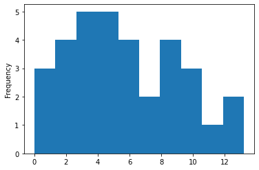

```python
df['Pts_per_g'].plot.hist();
```

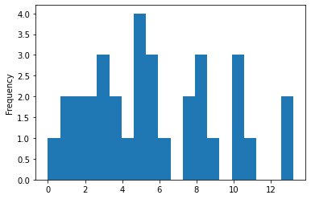

```python
df['Pts_per_g'].plot.hist(bins=20);
```

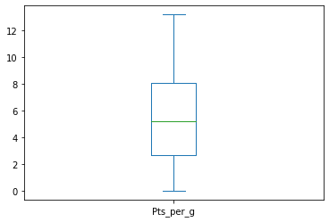

```python
df['Pts_per_g'].plot.box();
```

# Appendix: Web Crawling (Collecting data from multiple webpages) - MIS670

### Example: http://sfbay.craigslist.org/search/npo?s=

```python
a = "http://sfbay.craigslist.org/search/npo?s="
count = 0
for i in range(1,5):
    print('%s%s' %(a,count))
    count = count + 120
```

```
http://sfbay.craigslist.org/search/npo?s=0
http://sfbay.craigslist.org/search/npo?s=120
http://sfbay.craigslist.org/search/npo?s=240
http://sfbay.craigslist.org/search/npo?s=360
```

```python
a = "http://sfbay.craigslist.org/search/npo?s="
count = 0
for i in range(1,4):
    webpage = '%s%s' %(a,count)
    count = count + 120
    r = requests.get(webpage)
    data = html.fromstring(r.text)

    for i in data.xpath("//div[@class='result-info']"):
        title = i.xpath("h3/a/text()")
        url = i.xpath("h3/a/@href")
        print(title, url)
```

### Example: http://econpy.pythonanywhere.com/ex/001

```python
a = "http://econpy.pythonanywhere.com/ex/00"
count = 1
b = ".html"
for i in range(1,5):
    webpage = '%s%s%s' %(a,count,b)
    count = count + 1
    r = requests.get(webpage)
    data = html.fromstring(r.text)

    for i in data.xpath("//div[@title='buyer-info']"):
        buyers = i.xpath("div[@title='buyer-name']/text()")
        prices = i.xpath("span[@class='item-price']/text()")
        print(buyers, prices)
```

### Example: http://www.basketball-reference.com/draft/BAA_1947.html

```python
a = "http://www.basketball-reference.com/draft/BAA_"
count = 1947
b = ".html"
for i in range(1,10):
    webpage = '%s%s%s' %(a,count,b)
    count = count + 1
    r = requests.get(webpage)
    data = html.fromstring(r.text)

    for i in data.xpath("//tbody/tr"):
        player = i.xpath("td[@data-stat='player']/@csk")
        pts_per_g = i.xpath("td[@data-stat='pts_per_g']/text()")
        print(player, pts_per_g)
```